# PCA_Spotify_songs

LMT

septiembre 2022

**Ejercicio**

1. Aplicar Pincipal Component Analysis (PCA) a una playlist de spotify, utilicen una lista propia o uno de los datos ubicados en el repositorio de la clase.
2. Graficar los 2 primeros componentes principales. Una grafica de scatteplot con las etiquetas del nombre de cada canción.

Cargar librerías

```r
suppressMessages(library(tidyverse))
suppressMessages(library(corrplot))
```

Leer los datos

```r
datos <- read_delim("/home/leonardo/Documentos/Acatlan/datos/spotify/top_50_global_2022_semana_36.txt", delim = "|")
glimpse(datos)
```

```
## Rows: 50
## Columns: 22
## $ danceability     <dbl> 0.520, 0.621, 0.911, 0.650, 0.835, 0.561, 0.798…
## $ energy           <dbl> 0.731, 0.782, 0.712, 0.715, 0.679, 0.965, 0.697…
## $ key              <dbl> 6, 2, 1, 5, 7, 7, 0, 7, 0, 7, 9, 1, 8, 3, 10, 2…
## $ loudness         <dbl> -5.338, -5.548, -5.105, -5.198, -5.329, -3.673,…
## $ mode             <dbl> 0, 1, 0, 0, 0, 0, 1, 1, 1, 0, 0, 1, 1, 0, 0, 1,…
## $ speechiness      <dbl> 0.0557, 0.0440, 0.0817, 0.2530, 0.0364, 0.0343,…
## $ acousticness     <dbl> 0.34200, 0.01250, 0.09010, 0.09930, 0.58300, 0.…
## $ instrumentalness <dbl> 1.01e-03, 3.30e-02, 2.68e-05, 2.91e-04, 1.98e-0…
## $ liveness         <dbl> 0.3110, 0.2300, 0.0933, 0.1260, 0.2180, 0.3710,…
## $ valence          <dbl> 0.662, 0.550, 0.425, 0.187, 0.850, 0.304, 0.745…
## $ tempo            <dbl> 173.930, 128.033, 92.005, 106.672, 124.980, 128…
## $ type             <chr> "audio_features", "audio_features", "audio_feat…
## $ id               <chr> "4Dvkj6JhhA12EX05fT7y2e", "2tTmW7RDtMQtBk7m2rYe…
## $ uri              <chr> "spotify:track:4Dvkj6JhhA12EX05fT7y2e", "spotif…
## $ track_href       <chr> "https://api.spotify.com/v1/tracks/4Dvkj6JhhA12…
## $ analysis_url     <chr> "https://api.spotify.com/v1/audio-analysis/4Dvk…
## $ duration_ms      <dbl> 167303, 198938, 178567, 243717, 162638, 175238,…
## $ time_signature   <dbl> 4, 4, 4, 4, 4, 4, 4, 4, 4, 4, 4, 4, 3, 4, 4, 4,…
## $ artist_name      <chr> "Harry Styles", "Bizarrap", "Bad Bunny", "Bad B…
## $ song_name        <chr> "As It Was", "Quevedo: Bzrp Music Sessions, Vol…
## $ num_top          <dbl> 1, 2, 3, 4, 5, 6, 7, 8, 9, 10, 11, 12, 13, 14, …
## $ popularity       <dbl> 93, 100, 98, 97, 95, 88, 91, 96, 94, 96, 92, 87…
```

Variables a conservar

```r
# variables a conservar
features <- c("danceability","energy","loudness","speechiness","acousticness","instrumentalness","liveness","valence", "duration_ms")
```

**Breve exploración de los datos**

Revisar la densidad de cada variable

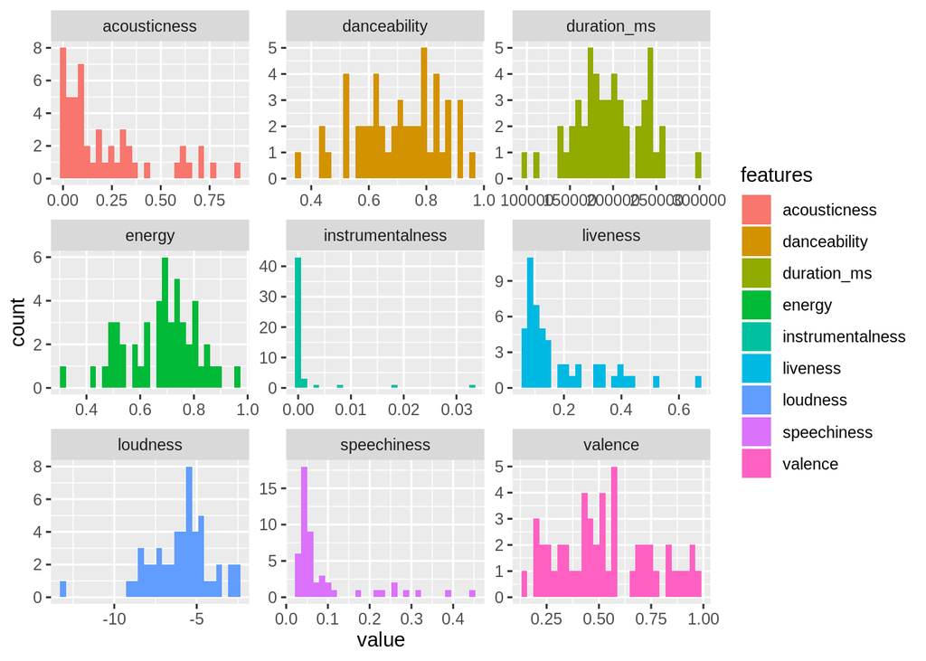

```r
datos %>% select(all_of(features)) %>%
  pivot_longer(cols = all_of(features), names_to = "features") %>%
  ggplot() +
    geom_histogram(aes(x = value, fill = features)) +
    facet_wrap(~features, scales = 'free')
```

Revisar correlación entre variables

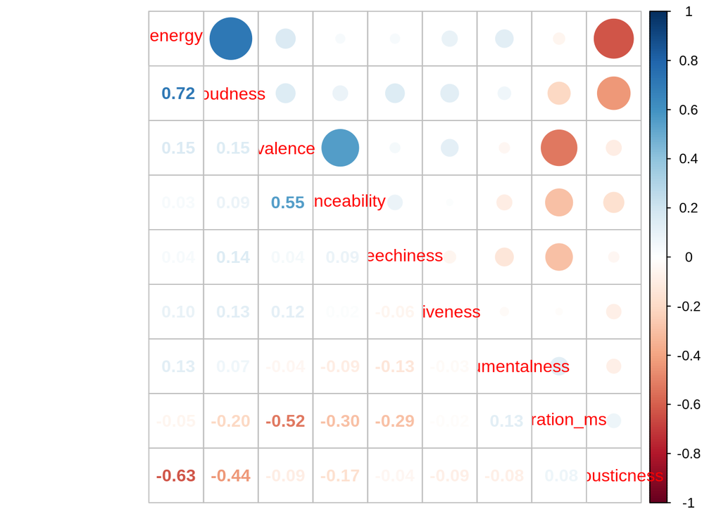

```r
#Calcular la matriz de correlación
M <- datos %>% select(all_of(features)) %>% cor()

# Graficar
M %>% corrplot.mixed(order = 'FPC')
```

Restarle la media a cada variable para centrarlas en cero

```r
datos_pca <- datos %>%
  select(all_of(features)) %>%
  mutate(danceability_pca = danceability - mean(danceability),
         energy_pca = energy - mean(energy),
         loudness_pca = (loudness - mean(loudness)),
         speechiness_pca = speechiness - mean(speechiness),
         acousticness_pca = acousticness - mean(acousticness),
         instrumentalness_pca = instrumentalness - mean(instrumentalness),
         liveness_pca = liveness - mean(liveness),
         valence_pca = valence - mean(valence),
         duration_pca = (duration_ms - mean(duration_ms))/100000) %>%
        # Conservar las variables transformadas, son las que terminan con '_pca'
        select(ends_with("_pca"))

glimpse(datos_pca)
```

```
## Rows: 50
## Columns: 9
## $ danceability_pca     <dbl> -0.18146, -0.08046, 0.20954, -0.05146, 0.13…
## $ energy_pca           <dbl> 0.05126, 0.10226, 0.03226, 0.03526, -0.0007…
## $ loudness_pca         <dbl> 0.62334, 0.41334, 0.85634, 0.76334, 0.63234…
## $ speechiness_pca      <dbl> -0.039774, -0.051474, -0.013774, 0.157526, …
## $ acousticness_pca     <dbl> 0.12285196, -0.20664804, -0.12904804, -0.11…
## $ instrumentalness_pca <dbl> -0.000322312, 0.031667688, -0.001305512, -0…
## $ liveness_pca         <dbl> 0.126348, 0.045348, -0.091352, -0.058652, 0…
## $ valence_pca          <dbl> 0.12972, 0.01772, -0.10728, -0.34528, 0.317…
## $ duration_pca         <dbl> -0.2891726, 0.0271774, -0.1765326, 0.474967…
```

```r
# una forma más eficiente de centrar los datos es:
  # scale(datos %>% all_of(features), scale = FALSE) %>% as.data.frame
```

**Aplicar PCA**

```r
spotify_pca <- datos_pca %>% prcomp()
```

Proporción de varianza explicada por cada componente principal

```r
summary(spotify_pca)
```

```
## Importance of components:
##                           PC1     PC2     PC3     PC4    PC5     PC6
## Standard deviation     1.9252 0.42035 0.22549 0.19683 0.1374 0.11242
## Proportion of Variance 0.9226 0.04398 0.01266 0.00964 0.0047 0.00315
## Cumulative Proportion  0.9226 0.96654 0.97919 0.98884 0.9935 0.99668
##                            PC7     PC8      PC9
## Standard deviation     0.09028 0.07170 0.005195
## Proportion of Variance 0.00203 0.00128 0.000010
## Cumulative Proportion  0.99871 0.99999 1.000000
```

Los objetos que nos regresa la función son

```r
names(spotify_pca)
```

```
## [1] "sdev"     "rotation" "center"   "scale"    "x"
```

Por medio del objeto sdev podemos obtener la varianza explicada por cada componente principal

```r
round((spotify_pca$sdev**2) / sum(spotify_pca$sdev**2),5)
```

```
## [1] 0.92256 0.04398 0.01266 0.00964 0.00470 0.00315 0.00203 0.00128 0.00001
```

Los eigenvectores son devueltos en el objeto ‘rotation’, estos son los escalares que se usan para formar la nuevas variables no correlacionadas a partir de las variables originales.

```r
spotify_pca$rotation
```

```
##                               PC1          PC2          PC3           PC4
## danceability_pca      0.007093881 -0.136843636  0.215225991  3.536896e-01
## energy_pca            0.049139661  0.026861359  0.229366459 -3.476343e-02
## loudness_pca          0.996021409  0.047345294 -0.062095850  2.026666e-02
## speechiness_pca       0.007442611 -0.058602616 -0.039937478 -9.440241e-02
## acousticness_pca     -0.055170699 -0.003358409 -0.895481168  3.700572e-01
## instrumentalness_pca  0.000180070  0.001799909  0.001525952  7.939595e-05
## liveness_pca          0.009364911 -0.003698360  0.057312926  1.155935e-01
## valence_pca           0.018420434 -0.352726835  0.272552166  7.720322e-01
## duration_pca         -0.044159691  0.922188715  0.127120409  3.435618e-01
##                                PC5          PC6          PC7          PC8
## danceability_pca     -0.2461033685  0.810574093 -0.185415415 -0.240452994
## energy_pca            0.0060296262 -0.296047222  0.075113051 -0.921797081
## loudness_pca         -0.0088178687  0.012143969 -0.008997880  0.033570009
## speechiness_pca      -0.0877761092  0.233534442  0.961094265 -0.004973495
## acousticness_pca     -0.0038473386  0.002876261 -0.002942696 -0.241005390
## instrumentalness_pca -0.0007131941 -0.006102346 -0.004446162 -0.002049019
## liveness_pca          0.9639188958  0.222010447  0.047250192 -0.050861578
## valence_pca          -0.0197120959 -0.388951534  0.159090018  0.167162212
## duration_pca         -0.0455067081 -0.004735494  0.092872828  0.051989582
##                                PC9
## danceability_pca     -3.342440e-03
## energy_pca            3.761662e-03
## loudness_pca          7.482974e-05
## speechiness_pca      -5.798269e-03
## acousticness_pca     -8.609882e-04
## instrumentalness_pca -9.999663e-01
## liveness_pca         -2.056517e-03
## valence_pca           1.183395e-03
## duration_pca          1.415106e-03
```

**Interpretación**. La primera componente separa las canciones por medio del volumen (loudness), la segunda componente parece oponer valance contra duración.

Validemos que las 9 variables nuevas (componentes principales) no están correlacionadas.

```r
z <- spotify_pca$x
round(t(z)%*%z,2)
```

```
##        PC1  PC2  PC3 PC4  PC5  PC6 PC7  PC8 PC9
## PC1 181.61 0.00 0.00 0.0 0.00 0.00 0.0 0.00   0
## PC2   0.00 8.66 0.00 0.0 0.00 0.00 0.0 0.00   0
## PC3   0.00 0.00 2.49 0.0 0.00 0.00 0.0 0.00   0
## PC4   0.00 0.00 0.00 1.9 0.00 0.00 0.0 0.00   0
## PC5   0.00 0.00 0.00 0.0 0.93 0.00 0.0 0.00   0
## PC6   0.00 0.00 0.00 0.0 0.00 0.62 0.0 0.00   0
## PC7   0.00 0.00 0.00 0.0 0.00 0.00 0.4 0.00   0
## PC8   0.00 0.00 0.00 0.0 0.00 0.00 0.0 0.25   0
## PC9   0.00 0.00 0.00 0.0 0.00 0.00 0.0 0.00   0
```

Graficar las 2 primeras componentes

```r
tablaz <- data.frame(spotify_pca$x)
datos_proyeccion <- bind_cols((select(datos,artist_name,song_name)),(select(tablaz,PC1,PC2)))
glimpse(datos_proyeccion)
```

```
## Rows: 50
## Columns: 4
## $ artist_name <chr> "Harry Styles", "Bizarrap", "Bad Bunny", "Bad Bunny"…
## $ song_name   <chr> "As It Was", "Quevedo: Bzrp Music Sessions, Vol. 52"…
## $ PC1         <dbl> 0.63136023, 0.42672420, 0.86798557, 0.74157102, 0.63…
## $ PC2         <dbl> -0.255256246, 0.055739163, -0.110643745, 0.595314865…
```

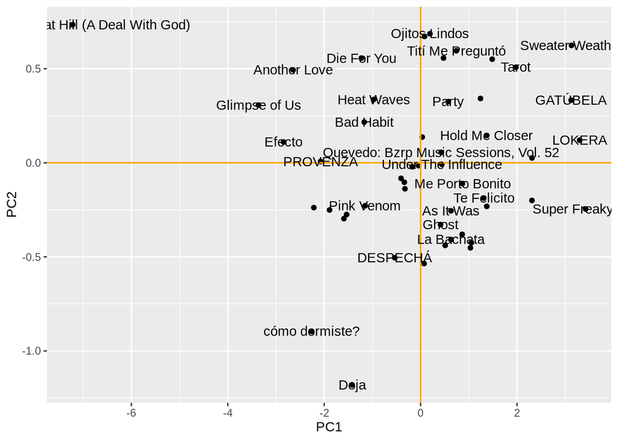

```r
ggplot(datos_proyeccion, aes(x = PC1, y = PC2)) +
  geom_point() +
    geom_hline(yintercept=0, color="orange", size=0.6) +
    geom_vline(xintercept=0, color="orange", size=0.6) +
      geom_text(label = datos_proyeccion$song_name, check_overlap = T)
```

Notar que si aplicamos SVD, la matriz V que contiene los vectores singulares derechos de la descomposición de la matriz A, equivalen a los eigenvetores obtenidos previamente aplicando PCA (pca$rotacion).

```r
# Nota. La función svd regresa 3 objetos:
        # d: vector con los valores singulares
        # u: matriz cuyas columnas son los vectores singulares izquierdos
        # v: matriz cuyas columnas son los vectores singulares derechos.
svd_A <- svd(datos_pca)
```

```r
#Notar que el objeto devuelto en la matrix V, es la matriz V y no la matriz V transpuesta.
svd_A$v
```

```
##               [,1]         [,2]         [,3]          [,4]          [,5]
##  [1,]  0.007093881 -0.136843636  0.215225991  3.536896e-01 -0.2461033685
##  [2,]  0.049139661  0.026861359  0.229366459 -3.476343e-02  0.0060296262
##  [3,]  0.996021409  0.047345294 -0.062095850  2.026666e-02 -0.0088178687
##  [4,]  0.007442611 -0.058602616 -0.039937478 -9.440241e-02 -0.0877761092
##  [5,] -0.055170699 -0.003358409 -0.895481168  3.700572e-01 -0.0038473386
##  [6,]  0.000180070  0.001799909  0.001525952  7.939595e-05 -0.0007131941
##  [7,]  0.009364911 -0.003698360  0.057312926  1.155935e-01  0.9639188958
##  [8,]  0.018420434 -0.352726835  0.272552166  7.720322e-01 -0.0197120959
##  [9,] -0.044159691  0.922188715  0.127120409  3.435618e-01 -0.0455067081
##               [,6]         [,7]         [,8]          [,9]
##  [1,]  0.810574093 -0.185415415 -0.240452994 -3.342440e-03
##  [2,] -0.296047222  0.075113051 -0.921797081  3.761662e-03
##  [3,]  0.012143969 -0.008997880  0.033570009  7.482974e-05
##  [4,]  0.233534442  0.961094265 -0.004973495 -5.798269e-03
##  [5,]  0.002876261 -0.002942696 -0.241005390 -8.609882e-04
##  [6,] -0.006102346 -0.004446162 -0.002049019 -9.999663e-01
##  [7,]  0.222010447  0.047250192 -0.050861578 -2.056517e-03
##  [8,] -0.388951534  0.159090018  0.167162212  1.183395e-03
##  [9,] -0.004735494  0.092872828  0.051989582  1.415106e-03
```